# Project 2: Data Mining, Classification, Prediction

SDS322E

# Mining, Classification, Prediction

## Jessica de Jong JLD4864

### Introduction

The data-set I’ve chosen contains data centered around potential heart failure in women and men. The variables in the data-set include age, sex, type of chest pain, resting blood pressure, resting ECG, MAX HR (heart rate), and whether or not the person had heart disease or not (1 or 0, respectively). The binary variable I’m focusing on is the heart disease variable. There are 918 observations in this data-set, with a total of twelve variables. For my binary variable, there is 410 people without heart disease, and 508 with heart disease. I found this data-set on Kaggle.com, under health-related data-sets.

```r
library(tidyverse)
# read your dataset
read_csv("heart.csv")
```

```
## # A tibble: 918 x 12
##      Age Sex   ChestPainType RestingBP Cholesterol FastingBS RestingECG MaxHR
##    <dbl> <chr> <chr>             <dbl>       <dbl>     <dbl> <chr>      <dbl>
##  1    40 M     ATA                 140         289         0 Normal       172
##  2    49 F     NAP                 160         180         0 Normal       156
##  3    37 M     ATA                 130         283         0 ST            98
##  4    48 F     ASY                 138         214         0 Normal       108
##  5    54 M     NAP                 150         195         0 Normal       122
##  6    39 M     NAP                 120         339         0 Normal       170
##  7    45 F     ATA                 130         237         0 Normal       170
##  8    54 M     ATA                 110         208         0 Normal       142
##  9    37 M     ASY                 140         207         0 Normal       130
## 10    48 F     ATA                 120         284         0 Normal       120
## # … with 908 more rows, and 4 more variables: ExerciseAngina <chr>,
## #   Oldpeak <dbl>, ST_Slope <chr>, HeartDisease <dbl>
```

```r
heart <- read_csv("heart.csv")

# observations for binary variable
sum(heart$HeartDisease == 0)
```

```
## [1] 410
```

```r
sum(heart$HeartDisease == 1)
```

```
## [1] 508
```

```r
# no tidying required
```

### Cluster Analysis

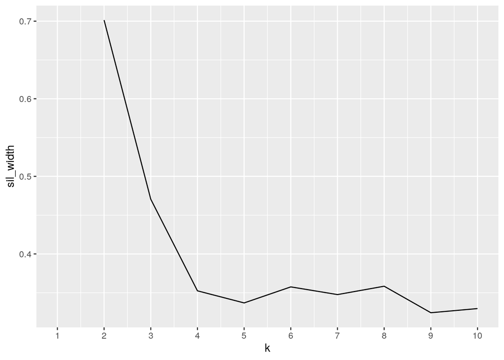

```r
# my installations install.packages('cluster')
# install.packages('GGally')

library(cluster)
library(GGally)

# MY CLUSTERING CODE

# three variables to cluster
heartpam <- heart %>% select(RestingBP, Cholesterol, MaxHR)


sil_width <- vector()

for (i in 2:10) {
    pam_fit <- pam(heartpam, k = i)
    sil_width[i] <- pam_fit$silinfo$avg.width
}

ggplot() + geom_line(aes(x = 1:10, y = sil_width)) + scale_x_continuous(name = "k",
    breaks = 1:10)
```

```r
pamh <- heartpam %>% pam(2)
print(pamh)
```

```
## Medoids:
##       ID RestingBP Cholesterol MaxHR
## [1,] 526       130         236   144
## [2,] 344       130           0   120
## Clustering vector:
##   [1] 1 1 1 1 1 1 1 1 1 1 1 1 1 1 1 1 1 1 1 1 1 1 1 1 1 1 1 1 1 1 1 1 1 1 1 1 1
##  [38] 1 1 1 1 1 1 1 1 1 1 1 1 1 1 1 1 1 1 1 1 1 1 1 1 1 1 1 1 1 1 1 1 1 1 1 1 1
##  [75] 1 1 1 1 2 1 1 1 1 1 1 1 1 1 1 1 1 1 1 1 1 1 1 1 2 1
##  [ reached getOption("max.print") -- omitted 818 entries ]
## Objective function:
##    build     swap
## 52.34769 50.01388
##
## Available components:
##  [1] "medoids"    "id.med"     "clustering" "objective"  "isolation"
##  [6] "clusinfo"   "silinfo"    "diss"       "call"       "data"
```

```r
heartpam %>% slice(pamh$id.med)
```

```
## # A tibble: 2 x 3
##   RestingBP Cholesterol MaxHR
##       <dbl>       <dbl> <dbl>
## 1       130         236   144
## 2       130           0   120
```

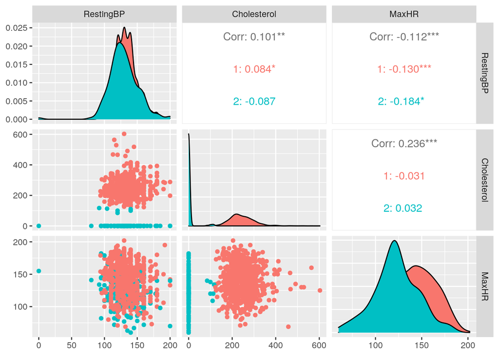

```r
ggpairs(heartpam, columns = 1:3, aes(color = as.factor(pamh$clustering)))
```

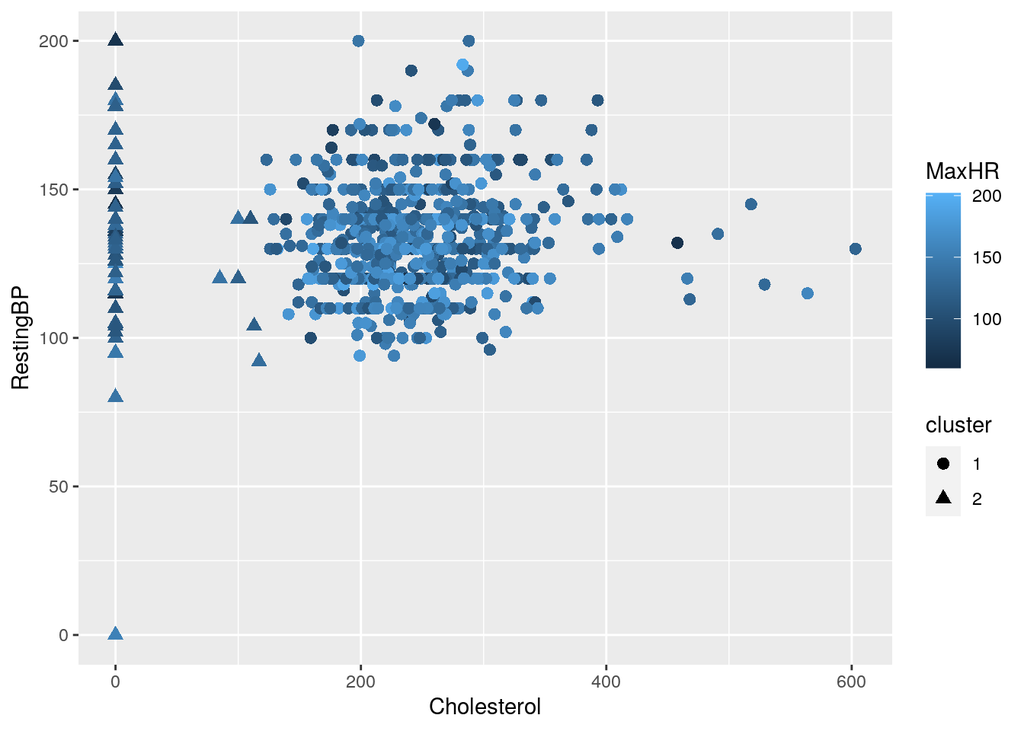

```r
pamcluster <- heartpam %>% mutate(cluster = as.factor(pamh$clustering))

pamcluster %>% ggplot(aes(Cholesterol, RestingBP, color = MaxHR,
    shape = cluster)) + geom_point(size = 2.5)
```

[figure not shown]

```r
plot(pamh, which = 2)
```

```r
pamh$silinfo$avg.width
```

```
## [1] 0.7013589
```

In my clustering analysis, I chose to zone in on the variables of cholesterol level, resting blood pressure, and maximum heart rate for the binary variable of heart disease. The optimal clustering for was a value of two.

In the first cluster, the medoid is ID 526, and in the second cluster, the medoid is ID #344.

The silhouette width was a value of 0.7013589. This is a considerable goodness of fit value for my model - this is the same as the average silhouette width in the plot.

```r
# MY PCA CODE HERE

heart_PCA <- heart %>% select(Cholesterol, RestingBP, MaxHR) %>%
    select_if(is.numeric) %>% scale

pcah <- princomp(heart_PCA)

summary(pcah, loadings = T)
```

```
## Importance of components:
##                           Comp.1    Comp.2    Comp.3
## Standard deviation     1.1112074 1.0353290 0.8306889
## Proportion of Variance 0.4120428 0.3576917 0.2302655
## Cumulative Proportion  0.4120428 0.7697345 1.0000000
##
## Loadings:
##             Comp.1 Comp.2 Comp.3
## Cholesterol  0.697  0.341  0.631
## RestingBP           0.898 -0.438
## MaxHR        0.716 -0.279 -0.640
```

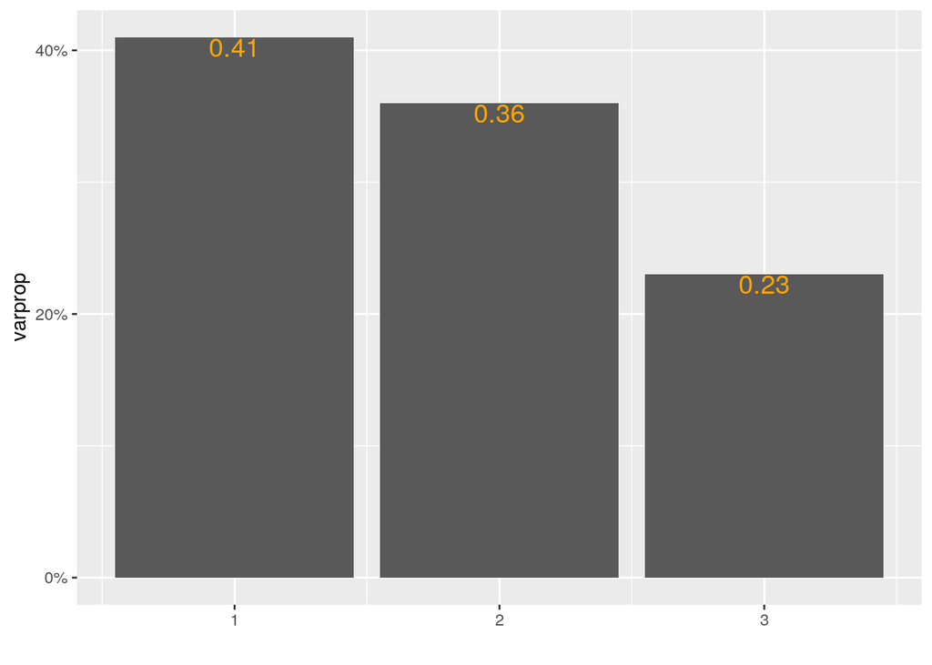

```r
eigvalue <- pcah$sdev^2
varprop = round(eigvalue/sum(eigvalue), 2)

ggplot() + geom_bar(aes(y = varprop, x = 1:3), stat = "identity") +
    xlab("") + geom_text(aes(x = 1:3, y = varprop, label = round(varprop,
    2)), vjust = 1, col = "orange", size = 5) + scale_y_continuous(breaks = seq(0,
    0.6, 0.2), labels = scales::percent) + scale_x_continuous(breaks = 1:10)
```

```r
round(cumsum(eigvalue)/sum(eigvalue), 2)
```

```
## Comp.1 Comp.2 Comp.3
##   0.41   0.77   1.00
```

```r
# what is eivgvalue?
eigvalue
```

```
##   Comp.1   Comp.2   Comp.3
## 1.234782 1.071906 0.690044
```

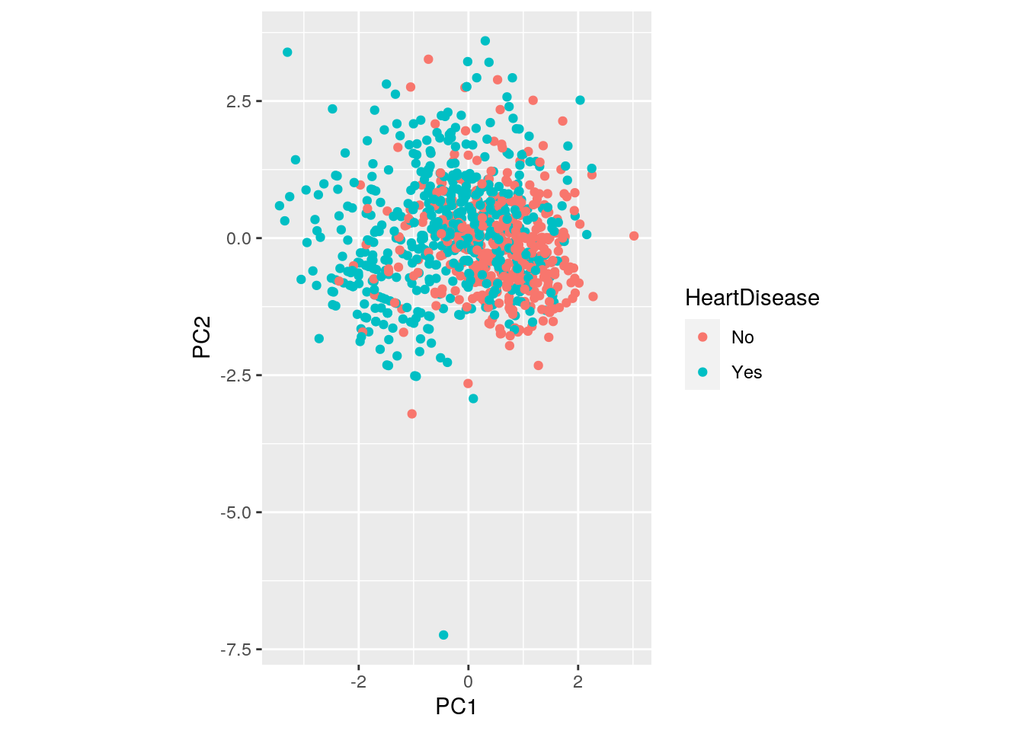

```r
heart_PCA <- as.data.frame(heart_PCA)
heart_PCA$HeartDisease <- heart$HeartDisease
heart_PCA$HeartDisease <- ifelse(heart_PCA$HeartDisease == 1,
    "Yes", "No")

# plot scores in rspect to first 2 PCS

heart_PCA %>% mutate(PC1 = pcah$scores[, 1], PC2 = pcah$scores[,
    2]) %>% ggplot(aes(PC1, PC2, color = HeartDisease)) + geom_point() +
    coord_fixed()
```

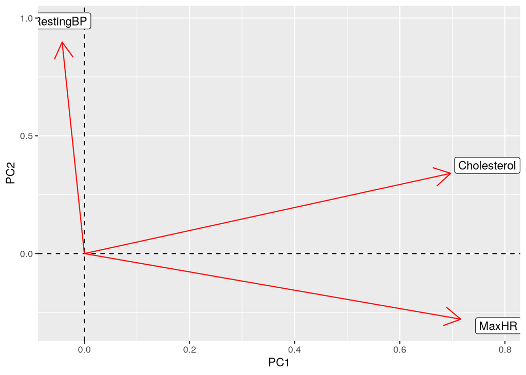

```r
# new coordinates; which vars contribute to which PCS

pcah$loadings[1:3, 1:2] %>% as.data.frame %>% rownames_to_column %>%
    ggplot() + geom_hline(aes(yintercept = 0), lty = 2) + geom_vline(aes(xintercept = 0),
    lty = 2) + ylab("PC2") + xlab("PC1") + geom_segment(aes(x = 0,
    y = 0, xend = Comp.1, yend = Comp.2), arrow = arrow(), col = "red") +
    geom_label(aes(x = Comp.1 * 1.1, y = Comp.2 * 1.1, label = rowname))
```

I found the optimal number of PCs was two (found form eigen values) and the model accounts for 77% of the variance.

When PC1 scores high, Cholesterol and Max HR are directly correlated. When cholesterol levels are igh, max HR is high.

### Linear Classifier

```r
# install ...  install.packages('caret')
library(caret)

# MY LINEAR CLASSIFIER CODE

# fit model, predictions for observations

heart$HeartDisease <- as.numeric(heart$HeartDisease)
fit <- glm(HeartDisease ~ Cholesterol + RestingBP + Age + MaxHR,
    data = heart, family = binomial)
summary(fit)
```

```
##
## Call:
## glm(formula = HeartDisease ~ Cholesterol + RestingBP + Age +
##     MaxHR, family = binomial, data = heart)
##
## Deviance Residuals:
##     Min       1Q   Median       3Q      Max
## -2.2915  -0.9722   0.4839   0.9328   1.9788
##
## Coefficients:
##               Estimate Std. Error z value Pr(>|z|)
## (Intercept)  2.2157258  0.8690180   2.550   0.0108 *
## Cholesterol -0.0037167  0.0007581  -4.903 9.46e-07 ***
## RestingBP    0.0075932  0.0042609   1.782   0.0747 .
## Age          0.0346815  0.0088579   3.915 9.03e-05 ***
## MaxHR       -0.0296254  0.0034722  -8.532  < 2e-16 ***
## ---
## Signif. codes:  0 '***' 0.001 '**' 0.01 '*' 0.05 '.' 0.1 ' ' 1
##
## (Dispersion parameter for binomial family taken to be 1)
##
##     Null deviance: 1262.1  on 917  degrees of freedom
## Residual deviance: 1055.8  on 913  degrees of freedom
## AIC: 1065.8
##
## Number of Fisher Scoring iterations: 4
```

```r
score <- predict(fit, type = "response")
head(score)
```

```
##         1         2         3         4         5         6
## 0.1818822 0.4599537 0.6297057 0.7177629 0.7085723 0.1398215
```

```r
heart$HeartDisease <- ifelse(heart$HeartDisease == 1, TRUE, FALSE)
heart$HeartDisease <- as.factor(heart$HeartDisease)

predicth <- predict(fit, newdata = heart, type = "response")
table(data = predicth > 0.5, reference = heart$HeartDisease)
```

```
##        reference
## data    FALSE TRUE
##   FALSE   262  126
##   TRUE    148  382
```

```r
heart$HeartDisease <- ifelse(heart$HeartDisease == TRUE, 1, 0)

heart$HeartDisease <- as.numeric(heart$HeartDisease)

# classifying
class_diag(score, heart$HeartDisease, positive = 1)
```

```
##            acc  sens  spec    ppv    f1     ba    auc
## Metrics 0.7015 0.752 0.639 0.7208 0.736 0.6955 0.7626
```

```r
# MY CROSS VALIDATION CODE HERE

# number of folds
k = 5

# randomly order rows, create folds
datasample <- heart[sample(nrow(heart)), ]
folds <- cut(seq(1:nrow(heart)), breaks = k, labels = F)
diags <- NULL

# create training and test sets, test model, diagnostics
for (i in 1:k) {
    train <- datasample[folds != i, ]
    test <- datasample[folds == i, ]
    truth <- test$HeartDisease
    fit <- glm(HeartDisease ~ Cholesterol + RestingBP + MaxHR +
        Age, data = train, family = binomial)
    probs <- predict(fit, newdata = test, type = "response")
    diags <- rbind(diags, class_diag(probs, truth, positive = 1))
}

# overfitting ?
summarize_all(diags, mean)
```

```
##       acc    sens    spec     ppv      f1      ba     auc
## 1 0.69282 0.74744 0.62924 0.71418 0.72844 0.68836 0.76336
```

### Non-Parametric Classifier

```r
# install.packages('caret')
library(caret)
# MY NON-PARAMETRIC CLASSIFIER CODE

heart2 <- heart %>% select(MaxHR, Age, RestingBP, Cholesterol,
    HeartDisease)

# fit that model
fit <- knn3(factor(HeartDisease == 1, levels = c("TRUE", "FALSE")) ~
    Cholesterol + MaxHR + Age + RestingBP, data = heart2, k = 5)

y_hat <- predict(fit, newdata = heart2)
y_hat %>% head(4)
```

```
##      TRUE FALSE
## [1,]  0.4   0.6
## [2,]  0.2   0.8
## [3,]  0.8   0.2
## [4,]  1.0   0.0
```

```r
# diagnostics
class_diag(y_hat[, 1], heart$HeartDisease, positive = 1)
```

```
##           acc   sens   spec    ppv     f1     ba    auc
## Metrics 0.781 0.8071 0.7488 0.7992 0.8031 0.7779 0.8659
```

```r
table(truth = factor(heart$HeartDisease == 1, levels = c("TRUE",
    "FALSE")), prediction = factor(y_hat[, 1] > 0.5, levels = c("TRUE",
    "FALSE")))
```

```
##        prediction
## truth   TRUE FALSE
##   TRUE   410    98
##   FALSE  103   307
```

```r
# my cross-validation of np classifier here
k = 3
data <- heart[sample(nrow(heart)), ]
folds <- cut(seq(1:nrow(heart)), breaks = k, labels = F)
diags <- NULL
for (i in 1:k) {
    train <- data[folds != i, ]
    test <- data[folds == i, ]
    truth <- test$HeartDisease
    fit <- knn3(HeartDisease ~ Cholesterol + MaxHR + RestingBP +
        Age, data = train)
    probs <- predict(fit, newdata = test)[, 2]
    diags <- rbind(diags, class_diag(probs, truth, positive = 1))
}

# overfitting ?
summarize_all(diags, mean)
```

```
##      acc      sens  spec       ppv        f1        ba       auc
## 1 0.7048 0.7561333 0.642 0.7239667 0.7388667 0.6990333 0.7533667
```

These two AUC values have more differences than the linear classifier, which means this model is less reliable. However, it is still somewhat good at predicting new observations. There are signs of overfitting here, more than the linear classifier.

### Regression/Numeric Prediction

```r
# my regression model code here
fit <- lm(Cholesterol ~ MaxHR + Age + RestingBP, data = heart)

yhat <- predict(fit)

mean((heart$Cholesterol - yhat)^2)
```

```
## [1] 11075.51
```

```r
# my cross-validation of regression model here

# my number of folds
k = 7
data <- heart[sample(nrow(heart)), ]
folds <- cut(seq(1:nrow(heart)), breaks = k, labels = F)
diags <- NULL
for (i in 1:k) {
    train <- data[folds != i, ]
    test <- data[folds == i, ]
    fit <- lm(Cholesterol ~ ., data = train)
    yhat <- predict(fit, newdata = test)
    diags <- mean((test$Cholesterol - yhat)^2)
}

mean(diags)
```

```
## [1] 12894.01
```

### Python

```r
# install.packages('reticulate')
library(reticulate)
use_python("/usr/bin/python3", required = F)
x <- heart$Cholesterol
y <- heart$MaxHR
```

```python
# my python code here
x = r.x
y = r.y
```

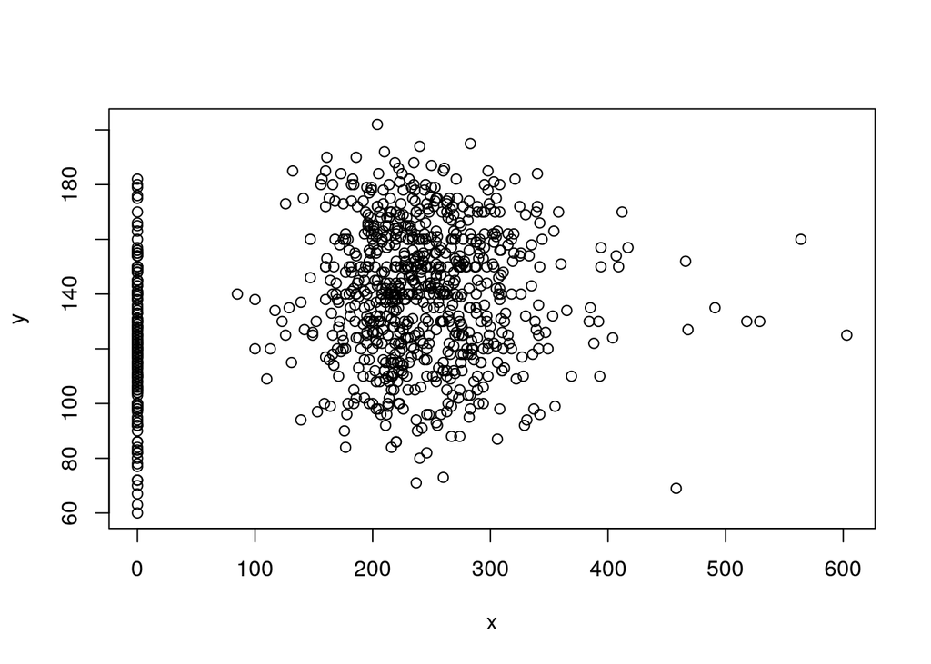

```r
x <- py$x
y <- py$y
plot(x, y)
```

For the python section, I made two r variables x and y. With the function r., I changed the two R variables into python variables. Then, I used the py$ function to turn these variables back into R. I plotted these variables in R Studio.

### Concluding Remarks

No concluding remarks. I enjoyed this class. Thank you to Nathan, Yiwei, and Ernesto for helping me and my classmates throughout the semester - and anyone else involved that I didn’t get to meet. (-: